# R Notebook

1. Read in the file, making the gene identifiers the row names. Show a table of values for the first six genes

```r
URL="https://raw.githubusercontent.com/ghazkha/Assessment4/refs/heads/main/gene_expression.tsv"
gene_expression_raw <- read.table(URL,stringsAsFactors = FALSE, header=TRUE, row.names=1)  #Reading the URL and formatting it correctly
head(gene_expression_raw)
```

|  | GTEX.1117F.0226.SM.5GZZ7 | GTEX.1117F.0426.SM.5EGHI | GTEX.1117F.0526.SM.5EGHJ |
| --- | --- | --- | --- |
| ENSG00000223972.5_DDX11L1 | 0 | 0 | 0 |
| ENSG00000227232.5_WASH7P | 187 | 109 | 143 |
| ENSG00000278267.1_MIR6859-1 | 0 | 0 | 1 |
| ENSG00000243485.5_MIR1302-2HG | 1 | 0 | 0 |
| ENSG00000237613.2_FAM138A | 0 | 0 | 0 |
| ENSG00000268020.3_OR4G4P | 0 | 1 | 0 |

2. Make a new column which is the mean of the other columns. Show a table of values for the first six genes.

```r
gene_expression <- gene_expression_raw #Create a new data set to modify, leave the original
gene_expression$Mean_Expression <- rowMeans(gene_expression_raw, na.rm = TRUE) #Finding the means of the rows, remove the empty values
head(gene_expression)
```

|  | GTEX.1117F.0226.SM.5GZZ7 | GTEX.1117F.0426.SM.5EGHI | GTEX.1117F.0526.SM.5EGHJ | Mean_Expression |
| --- | --- | --- | --- | --- |
| ENSG00000223972.5_DDX11L1 | 0 | 0 | 0 | 0.0000000 |
| ENSG00000227232.5_WASH7P | 187 | 109 | 143 | 146.3333333 |
| ENSG00000278267.1_MIR6859-1 | 0 | 0 | 1 | 0.3333333 |
| ENSG00000243485.5_MIR1302-2HG | 1 | 0 | 0 | 0.3333333 |
| ENSG00000237613.2_FAM138A | 0 | 0 | 0 | 0.0000000 |
| ENSG00000268020.3_OR4G4P | 0 | 1 | 0 | 0.3333333 |

3. List the 10 genes with the highest mean expression

```r
sorted_gene_expression <- gene_expression[order(-gene_expression$Mean_Expression), ] #Using the order function, sort the Mean expression in decreasing order
head(sorted_gene_expression,10) #Show the first 10
```

|  | GTEX.1117F.0226.SM.5GZZ7 | GTEX.1117F.0426.SM.5EGHI | GTEX.1117F.0526.SM.5EGHJ | Mean_Expression |
| --- | --- | --- | --- | --- |
| ENSG00000198804.2_MT-CO1 | 267250 | 1101779 | 218923 | 529317.3 |
| ENSG00000198886.2_MT-ND4 | 273188 | 991891 | 277628 | 514235.7 |
| ENSG00000198938.2_MT-CO3 | 250277 | 1041376 | 223178 | 504943.7 |
| ENSG00000198888.2_MT-ND1 | 243853 | 772966 | 194032 | 403617.0 |
| ENSG00000198899.2_MT-ATP6 | 141374 | 696715 | 151166 | 329751.7 |
| ENSG00000198727.2_MT-CYB | 127194 | 638209 | 141359 | 302254.0 |
| ENSG00000198763.3_MT-ND2 | 159303 | 543786 | 149564 | 284217.7 |
| ENSG00000211445.11_GPX3 | 464959 | 39396 | 306070 | 270141.7 |
| ENSG00000198712.1_MT-CO2 | 128858 | 545360 | 122816 | 265678.0 |
| ENSG00000156508.17_EEF1A1 | 317642 | 39573 | 339347 | 232187.3 |

4. Determine the number of genes with a mean <10

```r
sum(sorted_gene_expression$Mean_Expression <10)  #Use sum function which counts the number of TRUE expressions, each row with Mean_Expression less than 10 will be TRUE
```

```
[1] 35988
```

5. Make a histogram plot of the mean values

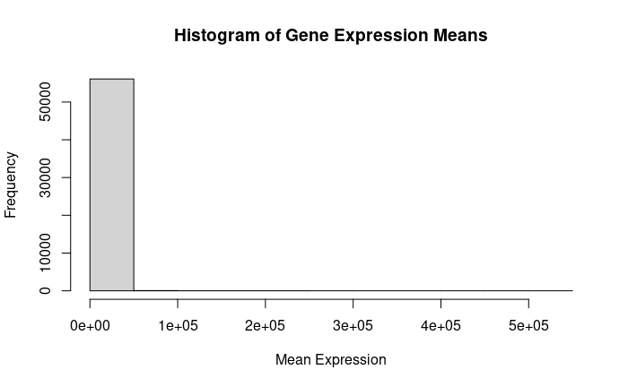

```r
# histogram
hist(gene_expression$Mean_Expression, xlab = "Mean Expression", main = "Histogram of Gene Expression Means")
```

Issue is we cannot see all the data, I think its best to log transform it

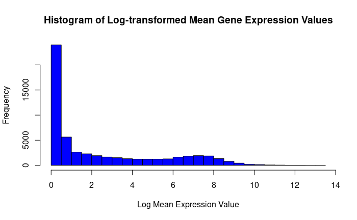

```r
# Log transformation of Mean values
log_means <- log(gene_expression$Mean_Expression + 1)

# Create a histogram using the transformed data
hist(log_means,
     main = "Histogram of Log-transformed Mean Gene Expression Values",
     xlab = "Log Mean Expression Value",
     ylab = "Frequency",
     col = "blue",
     border = "black",
     breaks = 30)
```

6. Import this csv file into an R object. What are the column names?

```r
URL= "https://raw.githubusercontent.com/ghazkha/Assessment4/refs/heads/main/growth_data.csv"
growth_data_raw <- read.csv(URL) #Read the csv
colnames(growth_data_raw) #Get the column names
```

```
[1] "Site"            "TreeID"          "Circumf_2005_cm" "Circumf_2010_cm" "Circumf_2015_cm" "Circumf_2020_cm"
```

7. Calculate the mean and standard deviation of tree circumference at the start and end of the study at both sites

```r
northeast_data <- growth_data_raw[growth_data_raw$Site == "northeast", ]

southwest_data <- growth_data_raw[growth_data_raw$Site == "southwest", ]

northeast_data_task7 <- northeast_data[, c("Circumf_2005_cm", "Circumf_2020_cm")]

southwest_data_task7 <- southwest_data[, c("Circumf_2005_cm", "Circumf_2020_cm")]

#Calculate Means for Northeast
mean(northeast_data_task7$Circumf_2005_cm, na.rm = TRUE)
```

```
[1] 5.292
```

```r
mean(northeast_data_task7$Circumf_2020_cm, na.rm = TRUE)
```

```
[1] 54.228
```

```r
#Calculate SD for Northeast
sd(northeast_data_task7$Circumf_2005_cm,na.rm=TRUE)
```

```
[1] 0.9140267
```

```r
sd(northeast_data_task7$Circumf_2020_cm,na.rm=TRUE)
```

```
[1] 25.22795
```

```r
#Calculate Means for Southwest
 mean(southwest_data_task7$Circumf_2005_cm, na.rm = TRUE)
```

```
[1] 4.862
```

```r
mean(southwest_data_task7$Circumf_2020_cm, na.rm = TRUE)
```

```
[1] 45.596
```

```r
#Calculate SD for Southwest
sd(southwest_data_task7$Circumf_2005_cm,na.rm=TRUE)
```

```
[1] 1.147471
```

```r
sd(southwest_data_task7$Circumf_2020_cm,na.rm=TRUE)
```

```
[1] 17.87345
```

```r
#Turn it into a data frame for northeast
northeast_results_task7 <- data.frame(
  Site = "northeast",  # Keep the site name in the first column
  mean_circumf_2005 = mean(northeast_data_task7$Circumf_2005_cm, na.rm = TRUE),
  sd_circumf_2005 = sd(northeast_data_task7$Circumf_2005_cm,na.rm=TRUE),
  mean_circumf_2020 = mean(northeast_data_task7$Circumf_2020_cm, na.rm = TRUE),
  sd_circumf_2020 = sd(northeast_data_task7$Circumf_2020_cm,na.rm=TRUE),
  stringsAsFactors = FALSE # Avoid converting strings to factors
)

#Turn it into a data frame for southwest
southwest_results_task7 <- data.frame(
  Site = "southwest",  # Keep the site name in the first column
  mean_circumf_2005 = mean(southwest_data_task7$Circumf_2005_cm, na.rm = TRUE),
  sd_circumf_2005 = sd(southwest_data_task7$Circumf_2005_cm,na.rm=TRUE),
  mean_circumf_2020 = mean(southwest_data_task7$Circumf_2020_cm, na.rm = TRUE),
  sd_circumf_2020 = sd(southwest_data_task7$Circumf_2020_cm,na.rm=TRUE),
  stringsAsFactors = FALSE # Avoid converting strings to factors
)

northeast_results_task7
```

| Site | mean_circumf_2005 | sd_circumf_2005 | mean_circumf_2020 | sd_circumf_2020 |
| --- | --- | --- | --- | --- |
| northeast | 5.292 | 0.9140267 | 54.228 | 25.22795 |

```r
southwest_results_task7
```

| Site | mean_circumf_2005 | sd_circumf_2005 | mean_circumf_2020 | sd_circumf_2020 |
| --- | --- | --- | --- | --- |
| southwest | 4.862 | 1.147471 | 45.596 | 17.87345 |

8. Make a box plot of tree circumference at the start and end of the study at both sites.

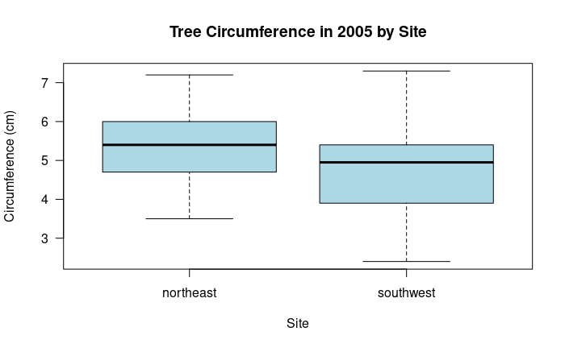

```r
northeast_task_8 <- data.frame(
  Circumference = c(northeast_data_task7$Circumf_2005_cm, northeast_data_task7$Circumf_2020_cm),
  Year = rep(c("2005", "2020"), each = nrow(northeast_data)),
  Site = "northeast"
)

# Create data for southwest site
southwest_task_8 <- data.frame(
  Circumference = c(southwest_data$Circumf_2005_cm, southwest_data$Circumf_2020_cm),
  Year = rep(c("2005", "2020"), each = nrow(southwest_data)),
  Site = "southwest"
)

# Combine the data into a single data frame for plotting purposes
combined_data_task8 <- rbind(northeast_task_8, southwest_task_8)

# Create a separate plot for 2005
boxplot(Circumference ~ Site,
        data = combined_data_task8[combined_data_task8$Year == "2005", ],
        main = "Tree Circumference in 2005 by Site",
        xlab = "Site",
        ylab = "Circumference (cm)",
        col = "lightblue",
        las = 1)
```

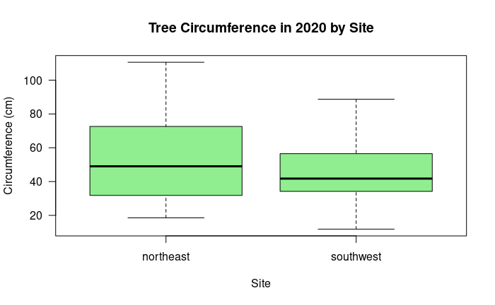

```r
# Create a separate plot for 2020
boxplot(Circumference ~ Site,
        data = combined_data_task8[combined_data_task8$Year == "2020", ],
        main = "Tree Circumference in 2020 by Site",
        xlab = "Site",
        ylab = "Circumference (cm)",
        col = "lightgreen",
        las = 1)
```

9. Calculate the mean growth over the last 10 years at each site

```r
northeast_data_task9 <- northeast_data[, c("Circumf_2010_cm", "Circumf_2020_cm")] #Subset the 2010 and 2020 data for northeast
southwest_data_task9 <- southwest_data[, c("Circumf_2010_cm", "Circumf_2020_cm")]#Subset the 2010 and 2020 data for southwest

northeast_results_task9 <- data.frame(
  Site = "northeast",  # Keep the site name in the first column
  mean_circumf_2010 = mean(northeast_data_task9$Circumf_2010_cm, na.rm = TRUE),
  sd_circumf_2010 = sd(northeast_data_task9$Circumf_2010_cm,na.rm=TRUE),
  mean_circumf_2020 = mean(northeast_data_task9$Circumf_2020_cm, na.rm = TRUE),
  sd_circumf_2020 = sd(northeast_data_task9$Circumf_2020_cm,na.rm=TRUE),
  stringsAsFactors = FALSE #Don't make strings as factors, because we have site name
)

southwest_results_task9 <- data.frame(
  Site = "southwest",  # Keep the site name in the first column
  mean_circumf_2010 = mean(southwest_data_task9$Circumf_2010_cm, na.rm = TRUE),
  sd_circumf_2010 = sd(southwest_data_task9$Circumf_2010_cm,na.rm=TRUE),
  mean_circumf_2020 = mean(southwest_data_task9$Circumf_2020_cm, na.rm = TRUE),
  sd_circumf_2020 = sd(southwest_data_task9$Circumf_2020_cm,na.rm=TRUE),
  stringsAsFactors = FALSE #Don't make strings as factors, because we have site name
)

Mean_Growth_northeast_10y <- northeast_results_task9$mean_circumf_2020 - northeast_results_task9$mean_circumf_2010 # Subtraction of 2020 and 2010 mean data
Mean_Growth_southwest_10y <- southwest_results_task9$mean_circumf_2020 - southwest_results_task9$mean_circumf_2010 # Subtraction of 2020 and 2010 mean data

#Display the results
Mean_Growth_northeast_10y
```

```
[1] 42.94
```

```r
Mean_Growth_southwest_10y
```

```
[1] 35.49
```

10. Use the t.test to estimate the p-value that the 10 year growth is different at the two sites.

```r
#Create the data set for this task, done via subtracting the 2020 data from the 2010 data for growth over 10 years
northeast_data_task10 <- data.frame(
  Growth_10yr = northeast_data_task9$Circumf_2020_cm - northeast_data_task9$Circumf_2010_cm)

southwest_data_task10 <- data.frame(
  Growth_10yr = southwest_data_task9$Circumf_2020_cm - southwest_data_task9$Circumf_2010_cm)

#Check if sd is the same, if they are not, then variances are not the same for t-test
sd(northeast_data_task10$Growth_10yr)
```

```
[1] 22.8151
```

```r
sd(southwest_data_task10$Growth_10yr)
```

```
[1] 16.05704
```

```r
#Assign t.test to a variable and print the results
t_test_result <- t.test(northeast_data_task10$Growth_10yr, southwest_data_task10$Growth_10yr)
print(t_test_result)
```

```
    Welch Two Sample t-test

data:  northeast_data_task10$Growth_10yr and southwest_data_task10$Growth_10yr
t = 1.8882, df = 87.978, p-value = 0.06229
alternative hypothesis: true difference in means is not equal to 0
95 percent confidence interval:
 -0.3909251 15.2909251
sample estimates:
mean of x mean of y
    42.94     35.49
```